# nguyen_nyt_opinion_pieces slides

## Implementing a News Reader

## Topic Modeling and Sentiment Analysis

We will look at New York Times Opinion articles and see what topics are currently talked about. We will then build a simple model looking at the an author's sentiments.

### Get articles

First we'll get some recent NYT opinion articles using the NYT Times Newswire API:

```python
df_articles.head(5)
```

|  | url | title | author | article_text |
| --- | --- | --- | --- | --- |
| 0 | https://www.nytimes.com/2021/07/03/opinion/ant... | The Excesses of Antiracist Education | Ross Douthat | The first idea is associated with Robin DiAnge... |
| 1 | https://www.nytimes.com/2021/07/03/opinion/err... | Donald Rumsfeld’s Fog of Memos | Errol Morris | Trying to understand another human being is of... |
| 2 | https://www.nytimes.com/2021/07/03/opinion/cov... | How Do You Convince Tough-Minded People to Pro... | Dana Liebelson | Jalissa Fletcher, a vice president of Cheyenne... |
| 3 | https://www.nytimes.com/2021/07/03/opinion/pre... | Friends in High Places | Maureen Dowd | WASHINGTON — When you are the president’s best... |
| 4 | https://www.nytimes.com/2021/07/03/opinion/let... | Debating the Morality and Value of Zoos |  | To the Editor:\n\nRe “The Case Against Zoos,” ... |

### Preprocessing

We will remove stopwords, punctuation and convert the text to lowercase.

```python
df_articles.sample(5)
```

|  | url | title | author | article_text | article_text_processed |
| --- | --- | --- | --- | --- | --- |
| 20 | https://www.nytimes.com/2021/07/02/opinion/ame... | Snap Out of It, America! | Ezekiel Kweku,Daniel Immerwahr,Jonathan Hollow... | This article originally appeared in the Opinio... | this article originally appeared opinion today... |
| 3 | https://www.nytimes.com/2021/07/03/opinion/pre... | Friends in High Places | Maureen Dowd | WASHINGTON — When you are the president’s best... | washington when president best friend may c... |
| 59 | https://www.nytimes.com/2021/06/29/opinion/let... | ‘What’s So Bad About Having Fewer or No Childr... |  | To the Editor:\n\n“The Birthrate Is Falling? T... | to editor the birthrate is falling that no... |
| 32 | https://www.nytimes.com/2021/07/01/opinion/us-... | The Rest of the World Is Worried About America | Ezra Klein | This is evident in our institutions. A society... | this evident institutions a society valued de... |
| 1 | https://www.nytimes.com/2021/07/03/opinion/err... | Donald Rumsfeld’s Fog of Memos | Errol Morris | Trying to understand another human being is of... | trying understand another human often dismal t... |

### Topic Modeling

```python
text_clustering = Pipeline([('vect', TfidfVectorizer(stop_words='english', ngram_range=(1,3))),
                     ('clustering', KMeans(n_clusters=12))])

text_clustering.fit(df_articles['article_text_processed'])
df_articles['cluster_assignment'] = text_clustering.predict(df_articles['article_text_processed'])
df_articles.head()
```

|  | url | title | author | article_text | article_text_processed | cluster_assignment |
| --- | --- | --- | --- | --- | --- | --- |
| 0 | https://www.nytimes.com/2021/07/03/opinion/ant... | The Excesses of Antiracist Education | Ross Douthat | The first idea is associated with Robin DiAnge... | the first idea associated robin diangelo seco... | 1 |
| 1 | https://www.nytimes.com/2021/07/03/opinion/err... | Donald Rumsfeld’s Fog of Memos | Errol Morris | Trying to understand another human being is of... | trying understand another human often dismal t... | 0 |
| 2 | https://www.nytimes.com/2021/07/03/opinion/cov... | How Do You Convince Tough-Minded People to Pro... | Dana Liebelson | Jalissa Fletcher, a vice president of Cheyenne... | jalissa fletcher vice president cheyenne cha... | 6 |
| 3 | https://www.nytimes.com/2021/07/03/opinion/pre... | Friends in High Places | Maureen Dowd | WASHINGTON — When you are the president’s best... | washington when president best friend may c... | 1 |
| 4 | https://www.nytimes.com/2021/07/03/opinion/let... | Debating the Morality and Value of Zoos |  | To the Editor:\n\nRe “The Case Against Zoos,” ... | to editor re the case against zoos emma ma... | 1 |

Create and generate word cloud images from the clusters:

```python
idx2word = {v:k for k,v in text_clustering.steps[0][1].vocabulary_.items()}
cluster_centers = text_clustering.steps[1][1].cluster_centers_
cluster_words = {}
for cluster_id, cluster_center in enumerate(cluster_centers):
    cluster_words[cluster_id] = [idx2word[idx] for idx in cluster_center.argsort()[-10:][::-1]]
```

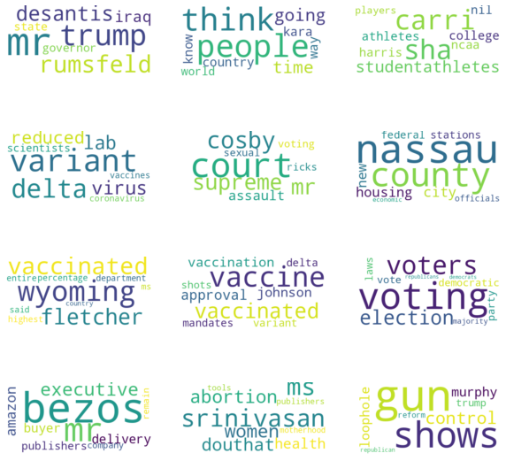

```python
plt.figure(figsize=(10, 10))
for idx, words in cluster_words.items():
    ax = plt.subplot(4, 3, idx + 1)
    words_string = (" ").join(words)
    wordcloud = WordCloud(background_color="white").generate(words_string)
    plt.imshow(wordcloud, interpolation='bilinear')
    plt.axis("off")
```

### Evaluation

Since this is clustering (unsupervised) without any ground truth labels, we'll evaluate the model with the silhouette score which gives a range of [-1, 1].

Silhouette coefficients near +1 indicate that the sample is far away from the neighboring clusters. A value of 0 indicates that the sample is on or very close to the decision boundary between two neighboring clusters and negative values indicate that those samples might have been assigned to the wrong cluster.

```python
from sklearn.metrics import silhouette_score

labels = text_clustering['clustering'].labels_
X = text_clustering.transform(df_articles['article_text_processed'])
silhouette_score(X, labels)
```

```
0.821131478640238
```

The Davies-Bouldin Index signifies the average ‘similarity’ between clusters, where the similarity is a measure that compares the distance between clusters with the size of the clusters themselves.

Zero is the lowest possible score, so values closer to zero indicate a better partition.

```python
from sklearn.metrics import davies_bouldin_score
davies_bouldin_score(X, labels)
```

```
0.17497638926418604
```

The Calinski-Harabasz index can also be used to evaluate the model, where a higher Calinski-Harabasz score relates to a model with better defined clusters.

```python
from sklearn.metrics import calinski_harabasz_score
calinski_harabasz_score(X, labels)
```

```
926.6836145273867
```

### Sentiment Analysis

Now we will perform some sentiment analysis on the opinion articles using spaCyTextBlob.

```python
nlp = spacy.load("en_core_web_sm")
nlp.add_pipe('spacytextblob')
```

```
<spacytextblob.spacytextblob.SpacyTextBlob at 0x135019160>
```

```python
for idx, row in df_articles_sentiment.iterrows():
    doc = nlp(row['article_text'])
    df_articles_sentiment.at[idx,'polarity'] = doc._.polarity
    df_articles_sentiment.at[idx,'subjectivity'] = doc._.subjectivity
```

We can, for example, look at some opinion pieces where the sentiment is more negative:

```python
df_articles_sentiment[df_articles_sentiment['polarity'] < 0.0].sample(3)
```

|  | url | title | author | article_text | article_text_processed | cluster_assignment | polarity | subjectivity |
| --- | --- | --- | --- | --- | --- | --- | --- | --- |
| 93 | https://www.nytimes.com/2021/06/25/opinion/cor... | Where Did the Coronavirus Come From? What We A... | Zeynep Tufekci | They have refused to share direct records from... | they refused share direct records lab dr shi ... | 3 | -0.017914 | 0.443460 |
| 95 | https://www.nytimes.com/2021/06/25/opinion/tru... | America Is Getting Meaner | Timothy Egan | I went to see my doctor the other day for a Co... | i went see doctor day coviddelayed physical i... | 1 | -0.031485 | 0.587406 |
| 94 | https://www.nytimes.com/2021/06/25/opinion/imr... | Opinion Q. and A.: Imran Khan Urges a New U.S.... | Yara Bayoumy,Jyoti Thottam | So there was this mistrust between the two cou... | so mistrust two countries and people pakistan... | 1 | -0.037605 | 0.329715 |

### Get more articles from Goldberg

We will get more articles by Goldberg using the NYT Article Search API.

```python
goldberg_articles = goldberg_articles[['web_url', 'byline']]

for index, row in goldberg_articles.iterrows():
    article = Article(row['web_url'])
    article.download()
    article.parse()
    goldberg_articles.at[index,'article_text'] = article.text

goldberg_articles
```

|  | web_url | byline | article_text |
| --- | --- | --- | --- |
| 0 | https://www.nytimes.com/2021/07/02/opinion/vac... | {'original': 'By Michelle Goldberg', 'person':... | The evidentiary void around J.&J. seemed to gr... |
| 1 | https://www.nytimes.com/2021/06/28/opinion/cri... | {'original': 'By Michelle Goldberg', 'person':... | Parents protesting critical race theory, he wr... |
| 2 | https://www.nytimes.com/2021/06/24/opinion/ind... | {'original': 'By Michelle Goldberg', 'person':... | That danger is real. Polls reveal that both Bl... |
| 3 | https://www.nytimes.com/2021/06/21/opinion/nyc... | {'original': 'By Michelle Goldberg', 'person':... | Last week I wrote about why I thought Eric Ada... |
| 4 | https://www.nytimes.com/2021/06/18/opinion/nyc... | {'original': 'By Michelle Goldberg', 'person':... | So I can hardly believe I’m going to put Adams... |
| 5 | https://www.nytimes.com/2021/06/14/opinion/sam... | {'original': 'By Michelle Goldberg', 'person':... | President Biden, however, is still a believer.... |
| 6 | https://www.nytimes.com/2021/06/07/opinion/acl... | {'original': 'By Michelle Goldberg', 'person':... | I have a foggy childhood memory of being home ... |
| 7 | https://www.nytimes.com/2021/06/04/opinion/sin... | {'original': 'By Michelle Goldberg', 'person':... | We are in the eye of the storm of American dem... |
| 8 | https://www.nytimes.com/2021/05/24/opinion/isr... | {'original': 'By Michelle Goldberg', 'person':... | Violence between Jews and Muslims in the Middl... |
| 9 | https://www.nytimes.com/2021/05/17/opinion/us-... | {'original': 'By Michelle Goldberg', 'person':... | But the explosion of fighting in Israel and Pa... |

```python
polarity_regressor = Pipeline([('vect', TfidfVectorizer(stop_words='english', ngram_range=(1,3))),
                     ('reg', LinearRegression())])

X = goldberg_articles.article_text
y = goldberg_articles.polarity

# This again gives the right predictions
polarity_regressor.fit(X, y)
goldberg_articles['pred_polarity'] = polarity_regressor.predict(X)
```

```python
goldberg_articles
```

|  | web_url | byline | article_text | polarity | subjectivity | pred_polarity |
| --- | --- | --- | --- | --- | --- | --- |
| 0 | https://www.nytimes.com/2021/07/02/opinion/vac... | {'original': 'By Michelle Goldberg', 'person':... | The evidentiary void around J.&J. seemed to gr... | 0.046883 | 0.438741 | 0.046883 |
| 1 | https://www.nytimes.com/2021/06/28/opinion/cri... | {'original': 'By Michelle Goldberg', 'person':... | Parents protesting critical race theory, he wr... | 0.080323 | 0.454070 | 0.080323 |
| 2 | https://www.nytimes.com/2021/06/24/opinion/ind... | {'original': 'By Michelle Goldberg', 'person':... | That danger is real. Polls reveal that both Bl... | 0.088406 | 0.428028 | 0.088406 |
| 3 | https://www.nytimes.com/2021/06/21/opinion/nyc... | {'original': 'By Michelle Goldberg', 'person':... | Last week I wrote about why I thought Eric Ada... | 0.090093 | 0.522319 | 0.090093 |
| 4 | https://www.nytimes.com/2021/06/18/opinion/nyc... | {'original': 'By Michelle Goldberg', 'person':... | So I can hardly believe I’m going to put Adams... | -0.056994 | 0.539650 | -0.056994 |
| 5 | https://www.nytimes.com/2021/06/14/opinion/sam... | {'original': 'By Michelle Goldberg', 'person':... | President Biden, however, is still a believer.... | 0.186382 | 0.418772 | 0.186382 |
| 6 | https://www.nytimes.com/2021/06/07/opinion/acl... | {'original': 'By Michelle Goldberg', 'person':... | I have a foggy childhood memory of being home ... | -0.002183 | 0.453241 | -0.002183 |
| 7 | https://www.nytimes.com/2021/06/04/opinion/sin... | {'original': 'By Michelle Goldberg', 'person':... | We are in the eye of the storm of American dem... | 0.114286 | 0.431190 | 0.114286 |
| 8 | https://www.nytimes.com/2021/05/24/opinion/isr... | {'original': 'By Michelle Goldberg', 'person':... | Violence between Jews and Muslims in the Middl... | 0.035985 | 0.264548 | 0.035985 |
| 9 | https://www.nytimes.com/2021/05/17/opinion/us-... | {'original': 'By Michelle Goldberg', 'person':... | But the explosion of fighting in Israel and Pa... | 0.153759 | 0.411216 | 0.153759 |

We're now going to use the model to predict Goldberg's sentiments on the other articles.

```python
df_articles_sentiment.sample(5)
```

|  | url | title | author | article_text | cluster_assignment | polarity | pred_polarity_by_goldberg |
| --- | --- | --- | --- | --- | --- | --- | --- |
| 64 | https://www.nytimes.com/2021/06/29/opinion/bla... | Black Valedictorians and the Toxic Trope of Bl... | Samuel Getachew | In his graduation speech last month, Mr. Muham... | 0 | 0.069060 | 0.074389 |
| 43 | https://www.nytimes.com/2021/06/30/opinion/cov... | Prioritizing People to Build Back the Economy | Rashida Tlaib,Eduardo Suplicy | Similar gains can be achieved in the United St... | 5 | 0.132132 | 0.082133 |
| 62 | https://www.nytimes.com/2021/06/29/opinion/kam... | Dear Kamala Harris: It’s a Trap! | Christina Greer | Ms. Harris is a complicated figure. She is not... | 1 | 0.127675 | 0.084821 |
| 16 | https://www.nytimes.com/2021/07/02/opinion/stu... | Make Americans’ Crushing Debt Disappear | Astra Taylor,Ezekiel Kweku,Daniel Immerwahr,Jo... | Formerly enslaved people called the phase that... | 1 | 0.132167 | 0.085555 |
| 95 | https://www.nytimes.com/2021/06/25/opinion/tru... | America Is Getting Meaner | Timothy Egan | I went to see my doctor the other day for a Co... | 1 | -0.031485 | 0.079636 |

Thank you for listening :)